# Recreating Part of the Monroe Writeup in RMD

Emilio Luz-Ricca

August 19, 2020

# Introduction

Crisis informatics is a “multidisciplinary field combining computing and social science knowledge of disasters; its central tenet is that people use personal information and communication technology to respond to disaster in creative ways to cope with uncertainty” (Palen and Anderson, 2016). The novel coronavirus (COVID), a pandemic that has devastated countries globally, certainly should be regarded as a crisis situation. Whereas many case studies within the field of crisis informatics focus on small-scale or relatively isolated crises, COVID is a crisis of unprecedented scale and with global implications. COVID provides an opportunity to reformulate underlying theory within crisis informatics as well as explore novel interactions amongst a broader range of participatory actors.

Twitter is an online microblogging platform that hosts a variety of content, with 330 million monthly active users in 2019.[^1] When using social media as a source of text data, Twitter is often used for their comparatively liberal policy on data availability. Specifically, Twitter offers tools to access their data through a public, but still somewhat restricted, application program interface (API). Once data has been collected, techniques from computational linguistics and natural language processing (NLP) can be applied using robust open source packages (Stanza, NLTK, spaCy, TextBlob, etc.) written for popular programming languages.

In particular, crisis informatics research has often used Twitter data in conjunction with NLP techniques to explore the complex roles of organizational entities and individuals during times of crisis (Reuter et al., 2018). Studies within this area of crisis informatics research often focus on the filtering of social media data to identify and summarize accurate information, building systems to aid crisis management organizations, and describing the ways in which citizens and authorities cooperate through social media during crisis situations (Reuter et al., 2018). Unfortunately, source data in crisis informatics research is heavily biased towards English Twitter data, reflecting both the stranglehold that social media sites have on “big text data” and the language-support limitations within NLP (Reuter et al., 2018). While I do not provide solutions to either of these problems, it is important to acknowledge this bias as a prevalent issue within crisis informatics and NLP research as a whole.

I am trying out different types of referencing: Baldwin et al. (2015) and (Baldwin et al., 2015; Reuter et al., 2018; Palen and Anderson, 2016). Or, perhaps, (i.e., Baldwin et al., 2015).

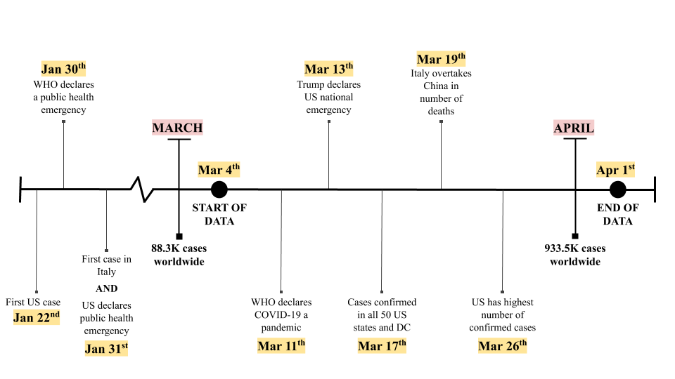

A timeline of key events occurring before and during the data collection period.

# Results

## SA Results

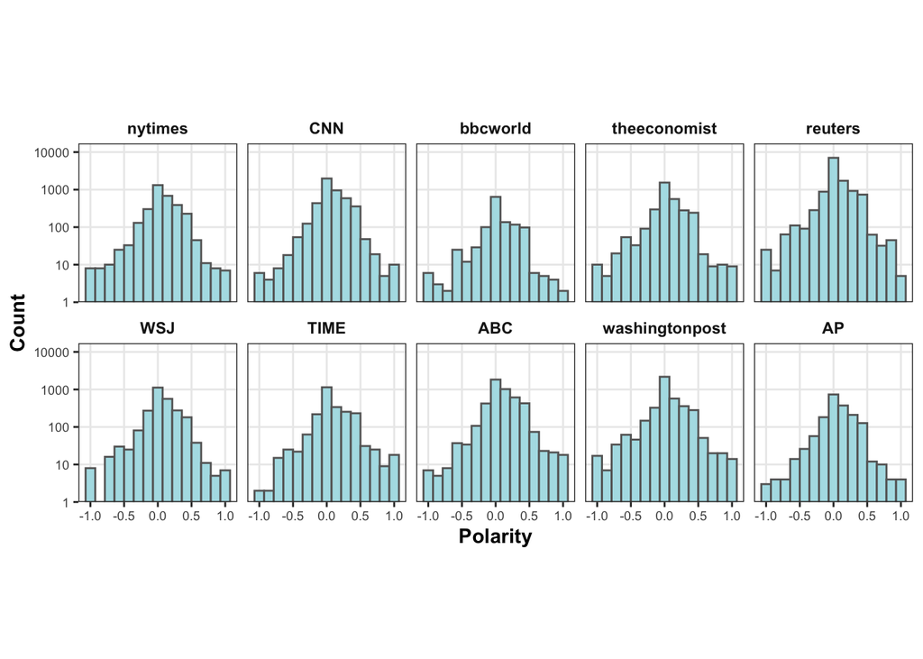

Polarity distributions for each news source on a logarithmic scale.

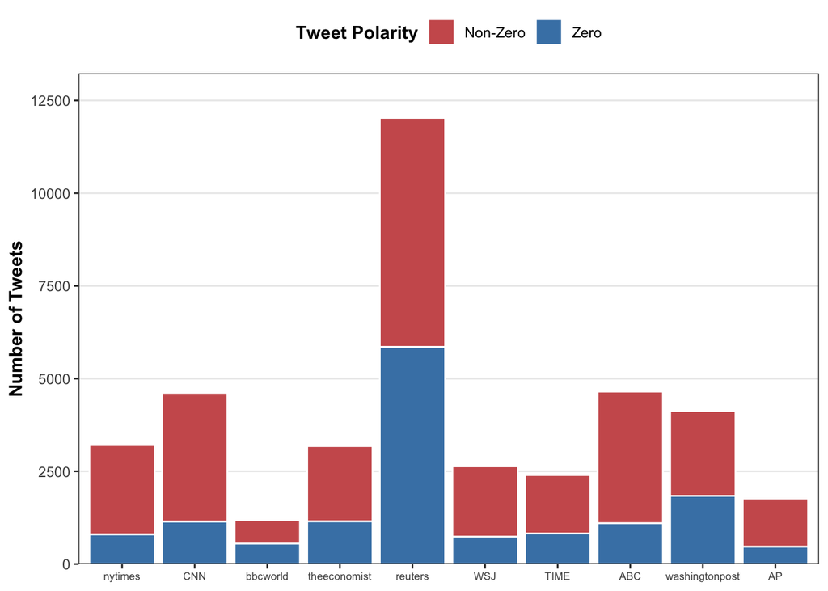

The proportion of zero- to nonzero-polarity tweets.

I split the data sets by COVID/non-COVID to see if there are any differences between the two subsets. For most news sources, both subsets tend to agree in their proportions. However, for Reuters and The Associated Press, 6.2% and 10.7% less tweets, respectively, were neutral in their COVID subset.

# Trying Out Proofs, Equations, and Theorems

$$\begin{equation}
r_k(i) = a^i + \delta \cdot \left( \frac{10e}{g^2} \right)
(\#eq:arbitrary-eq)
\end{equation}$$

Then we’ll try doing a short proof:

[output not shown]

# References

Timothy Baldwin, Marie-Catherine de Marneffe, Bo Han, Young-Bum Kim, Alan Ritter, and Wei Xu. 2015. Shared Tasks of the 2015 Workshop on Noisy User-generated Text: Twitter Lexical Normalization and Named Entity Recognition. In *Proceedings of the Workshop on Noisy User-generated Text*, pages 126–135, Beijing, China. Association for Computational Linguistics.

Leysia Palen and Kenneth M. Anderson. 2016. Crisis informatics—New data for extraordinary times. *Science*, 353(6296):224–225, July.

Christian Reuter, Amanda Lee Hughes, and Marc-André Kaufhold. 2018. Social Media in Crisis Management: An Evaluation and Analysis of Crisis Informatics Research. *International Journal of Human–Computer Interaction*, 34(4):280–294, April.

[^1]: https://www.statista.com/statistics/282087/number-of-monthly-active-twitter-users/